# 102a Homework 5

Joshua Susanto

2023-03-23

## 1: Root-Finding Problem

1. Write R code using the Bisection method to solve the following equations within an error of 10^−8.
1. x^3 + 23 = 0

```r
f_parta <- function(x) x^3 + 23
x_l <- -3
x_r <- -2
f_l <- f_parta(x_l)
f_r <- f_parta(x_r)
f_parta(x_l) * f_parta(x_r)
```

```
## [1] -60
```

So our interval will be [-3,-2]

$$(b-a)*(0.5)^n\leq10^{-8}\\
(-2+3)*(0.5)^n\leq10^{-8}\\
\log_{0.5}(0.5)^n\leq\log_{0.5}10^{-8}\\
n\geq26.57542475$$

Hence we expect 27 iterations for this problem

```r
tol <- 10^-8
its <- 0

while(x_r - x_l > tol) {
  x_m <- (x_l + x_r) / 2
  f_m <- f_parta(x_m)
  if(identical(all.equal(f_m,0),TRUE)){
    break
  }
  if(f_l * f_m < 0){
    x_r <- x_m
  } else{
    x_l <- x_m
  }
  its <- its + 1
}
x_m
```

```
## [1] -2.843867
```

```r
its
```

```
## [1] 27
```

2. x^x − 18 = 0

```r
f_partb <- function(x) x^x -18
x_l <- 2
x_r <- 3
f_l <- f_partb(x_l)
f_r <- f_partb(x_r)
f_partb(x_l) * f_partb(x_r)
```

```
## [1] -126
```

So our interval will be [2,3]

$$(b-a)*(0.5)^n\leq10^{-8}\\
(3-2)*(0.5)^n\leq10^{-8}\\
\log_{0.5}(0.5)^n\leq\log_{0.5}10^{-8}\\
n\geq26.57542475$$

Hence we expect 27 iterations for this problem

```r
tol <- 10^-8
its <- 0
while(x_r - x_l > tol) {
  x_m <- (x_l + x_r) / 2
  f_m <- f_partb(x_m)
  if(identical(all.equal(f_m,0),TRUE)){
    break
  }
  if(f_l * f_m < 0){
    x_r <- x_m
  } else{
    x_l <- x_m
  }
  its <- its + 1
}
its
```

```
## [1] 27
```

```r
x_m
```

```
## [1] 2.803663
```

3. e<sup>−x2</sup> − 1/10 = 0

```r
f_partc <- function(x) exp(-x^2) - 0.1
x_l <- 1
x_r <- 2
f_l <- f_partc(x_l)
f_r <- f_partc(x_r)
f_partc(x_l) * f_partc(x_r)
```

```
## [1] -0.02188156
```

So our interval will be [1,2]

$$(b-a)*(0.5)^n\leq10^{-8}\\
(2-1)*(0.5)^n\leq10^{-8}\\
\log_{0.5}(0.5)^n\leq\log_{0.5}10^{-8}\\
n\geq26.57542475$$

Hence we expect 27 iterations for this problem

```r
tol <- 10^-8
its <- 0

while(x_r - x_l > tol) {
  x_m <- (x_l + x_r) / 2
  f_m <- f_partc(x_m)
  if(f_l * f_m < 0){
    x_r <- x_m
  } else{
    x_l <- x_m
  }
  its <- its + 1
}
its
```

```
## [1] 27
```

```r
x_m
```

```
## [1] 1.517427
```

This function has two zeroes, the second one falls within [-2,-1]

```r
x_l <- -2
x_r <- -1
f_l <- f_partc(x_l)
f_r <- f_partc(x_r)
f_partc(x_l) * f_partc(x_r)
```

```
## [1] -0.02188156
```

$$(b-a)*(0.5)^n\leq10^{-8}\\
(-1-(-2))*(0.5)^n\leq10^{-8}\\
\log_{0.5}(0.5)^n\leq\log_{0.5}10^{-8}\\
n\geq26.57542475$$

Hence we expect 27 iterations for this problem

```r
tol <- 10^-8
its <- 0

while(x_r - x_l > tol) {
  x_m <- (x_l + x_r) / 2
  f_m <- f_partc(x_m)
  if(f_l * f_m < 0){
    x_r <- x_m
  } else{
    x_l <- x_m
  }
  its <- its + 1
}
its
```

```
## [1] 27
```

```r
x_m
```

```
## [1] -1.517427
```

2. Please write R code using the Fixed point iteration method to solve the equation (b). Explain your algorithm prior to the code. (explain which g you are using and why) Note: You may answer and write code for above two questions directly on Rmd file.

In order to start our fixed point algorithm, we need to find our three candidates for g(x) like so:

$$f(x) = x^x - 18 \\
g_1(x) = x - f(x) = -x^x + x - 18\\
g_2(x) = f(x) + x = x^x + x + 18\\
\\ Let \; f(x) = 0;\; 0 = x^x - 18\\
18 = x^x\\
ln(18) = ln(x)^x\\
ln(18) = xln(x)\\
g_3(x) = x = \frac{ln(18)}{ln(x)}$$

Now that we have our three candidates we need to check our convergence criterion for each case (with interval [2,3]) in order to find which choice of g will be best.

$$|g_1^{'}(x)| = |-x^x(1+ln(x)) +
1|\leq|g_1^{'}(3)|\;for\;x\in[2,3]\\
|g_1^{'}(3)| = |-55.66| > 1,\;so \;g_1(x)\; diverges\\
|g_2^{'}(x)| = |x^x(1+ln(x)) +
1|\leq|g_2^{'}(3)|\;for\;x\in[2,3]\\
|g_2^{'}(3)| = |-57.66| > 1,\;so \;g_2(x)\;
diverges\\$$

$$|g_3^{'}(x)| =
|-\frac{ln(18)}{xln^2(x)}|\\
|g_3^{'}(3) = |-0.798| < 1, \;so
\;g_3\;converges\;and\;will\;be\;used$$

Since 3 is within our range of attraction, we will use x = 3 as our starting point

```r
g <- function(x){
  log(18)/log(x)
}
x_1 <- 3
x_2 <- g(x_1)
i <- 0
tol <- 1e-8
while(abs(x_2 - x_1) > tol){
  x_1 <- x_2
  x_2 <- g(x_1)
  i <- i + 1
}
x_2
```

```
## [1] 2.803663
```

3. Use the Newton’s method to compute the square root by using only simple arithmetic operations1
1. Please write a function, get_sqrt(), that computes the square root of an arbitrary positive number. The function should take four arguments, the last three have default values:

a a non-negative number to compute the square root of.

tol determines when you consider two iterates to be equal.

iter max gives the maximum number of iterations.

verbose determines if you want to display intermediate results

#### **`get_sqrt()`**

**Algorithm:**

1. Check for errors and undesirable inputs.
2. Initialize function f to be x*x - a, this will be the function that we use Newton’s on
3. Initialize the derivative of f to be 2*x
4. Initialize iterations to be 0, and start loop to last while |f(x)| < tol and iterations < iter_max
5. Set x to be x minus f(x)/f’(x), add 1 to our iteration count
6. If verbose is true, print this value of x
7. Continue until loop breaks, return our final x value
2. Give an example of your function by computing the square root of 5.

```r
get_sqrt(5)
```

```
## [1] 2.236068
```

```r
get_sqrt(5, verbose = TRUE)
```

```
## [1] 3
## [1] 2.333333
## [1] 2.238095
## [1] 2.236069
## [1] 2.236068
```

```
## [1] 2.236068
```

3. How would the program change to compute an arbitrary, positive integer, root? Please use calculus to determine an appropriate iterative equation for approximating this arbitrary root.

This program’s internal function would change to determine an arbitrary root. In particular, the power of x will correspond to whatever root we decide to do.

$$Let\;f(x) = x^n-a \\
0 = x^n - a\\
x = \sqrt[n]{a}\\
0 = f(x_0) + f′(x_0)(x_1 − x_0)\\
0 = f(x_0) + f′(x_0)x_1 − f′(x_0)x_0\\
f′(x_0)x_1 = f′(x_0)x_0 − f(x_0)\\
x_1 = x_0 − \frac{f(x_0)}{f′(x_0)} \\
x_1= x_0 - \frac{x_0^n-a}{nx_0^{n-1}}$$

4. Write an R function, get_abroot(), like the one for square root which calculates the arbitrary root of a number. I.e., the root argument is required for the function.

#### **`get_abroot()`**

**Algorithm:**

1. Check for errors and undesirable inputs.
2. Initialize function f to be x^(root) - a, this will be the function that we use Newton’s on
3. Initialize the derivative of f to be root*x^(root-1)
4. Initialize iterations to be 0, and start loop to last while |f(x)| < tol and iterations < iter_max
5. Set x <- x - f(x)/f’(x), add 1 to our iteration count
6. If verbose is true, print this value of x
7. Continue until loop breaks, return our final x value
5. Give an example of your function by computing the seventh root of 13.

```r
get_abroot(13,7)
```

```
## [1] 1.442563
```

```r
get_abroot(13, 7, verbose = TRUE)
```

```
## [1] 11.14286
## [1] 9.551022
## [1] 8.186592
## [1] 7.017085
## [1] 6.01466
## [1] 5.155462
## [1] 4.419067
## [1] 3.788021
## [1] 3.247504
## [1] 2.785158
## [1] 2.391257
## [1] 2.059582
## [1] 1.789687
## [1] 1.590535
## [1] 1.478022
## [1] 1.445015
## [1] 1.442575
## [1] 1.442563
## [1] 1.442563
```

```
## [1] 1.442563
```

```r
results <- c(get_abroot(13, 7, iter_max = 1), get_abroot(13, 7, iter_max = 2), get_abroot(13, 7, iter_max = 3), get_abroot(13, 4, iter_max = 5))
abs(results - get_abroot(13,7))
```

```
## [1] 9.700295 8.108459 6.744030 1.709439
```

## 2. Optimization Problem

1. Using calculus, find the minimum of the function f(x) = x n − nα log(x), n = 1, 2, … and α > 0.

$$f(x) = x^n − n\alpha ln(x),\; n = 1, 2,
... \;and\;\alpha > 0 \\
f′(x)= nx^{n-1}-\frac{n\alpha}{x}\\
0 = nx^{n-1}-\frac{n\alpha}{x}\\
xnx^{n-1}= n\alpha\\
nx^{n}= n\alpha\\
x = \sqrt[n]\alpha$$

$$f′′(x) = n(n-1)x^{n-2}+n\alpha x^{-2}\\
f′′(\alpha) = n(n-1)\alpha^{n-2}+n\alpha \alpha^{-2} > 0 \; for \; n
= 1, 2, ... \;and\;\alpha > 0\\$$

Hence, by the second derivative test, the minimum of the function occus at x = n root of α

2. Using your formulas for the derivatives of f, write down Newton’s method to find the minimum.

$$f(x) = x^n − n\alpha ln(x),\; n = 1, 2,
... \;and\;\alpha > 0 \\
f′(x)= nx^{n-1}-\frac{n\alpha}{x}\\
f′′(x) = n(n-1)x^{n-2}+n\alpha x^{-2}\\
f′′(x_k)x_{k+1} = f′(x_k)x_k − f′(x_k)\\
x_{k+1} = x_k − \frac{f′(x_k)}{f′′(x_k)}\\
x_{k+1} = x_k −
\frac{nx_k^{n-1}-\frac{n\alpha}{x_k}}{n(n-1)x_k^{n-2}+n\alpha
x_k^{-2}}$$

3. Use R to write a function, get_min(), which takes the following arguments:

f an expression to minimize with respect to x

x an initial guess

… any additional variables needed by f

Choose an appropriate stopping rule and, using your function, return the minimum of f for n = 2 and α = 3

#### **`get_min()`**

**Algorithm:**

1. Check for errors and undesirable inputs.
2. Initialize function f_expr to be f
3. Find f_prime and f_dub_prime with D() function
4. Initialize iterations to be 0, and start loop to last while |f’(x)| < tol and iterations < iter_max
5. Set x <- x - f’(x)/f’’(x), add 1 to our iteration count
6. If verbose is true, print this value of x
7. Continue until loop breaks, return our final x value

```r
get_min(expression(x^n-n*a*log(x)), x = 1, n = 2, a = 3)
```

```
## [1] 1.732051
```

4. Plot the function and the steps taken by your method starting from x0 = 1

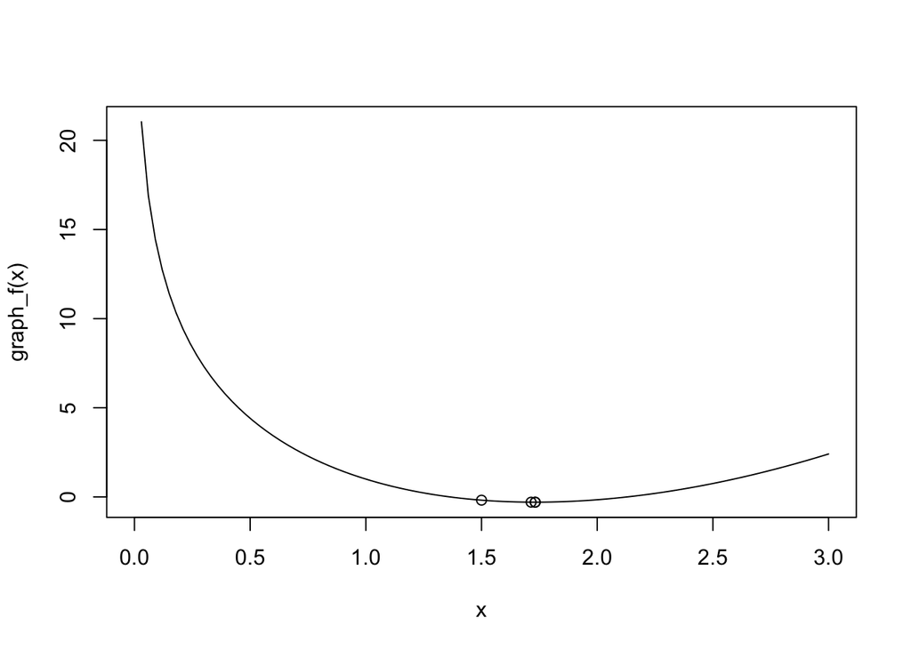

```r
f <- expression(x^2 - 6*log(x))
x <- c(get_min(expression(x^n-n*a*log(x)), x = 1, n = 2, a = 3, iter_max = 1),
           get_min(expression(x^n-n*a*log(x)), x = 1, n = 2, a = 3, iter_max = 2),
           get_min(expression(x^n-n*a*log(x)), x = 1, n = 2, a = 3, iter_max = 3),
           get_min(expression(x^n-n*a*log(x)), x = 1, n = 2, a = 3, iter_max = 4))
graph_f <- function(x) {
  x^2 - 6*log(x)
}
curve(graph_f, from = 0, to = 3)
points(x, eval(f))
```